# Lauren Gerber Master’s Thesis

2025-04-24

## Master’s Thesis Script

### Install necessary libraries, set options, and download GDP and Democracy Data from R packages.

```r
library(devtools)
library(tidyverse)
library(forcats)
devtools::install_github("vdeminstitute/vdemdata")
library(vdemdata)
library(car)
library(gtsummary)
library(WDI)
library(psych)

#set to not report in scientific notation
options(scipen = 5)
```

### Load Datasets, Rename Variables, and Keep Only Relevant Variables/Years for GDP and VDEM Datasets.

```r
#Make a data-set with chosen countries' GDP per capita adjusted for inflation and purchasing power parity.
#limit year to 2023, the end of survey collection.
gdp<- WDI(indicator="NY.GDP.PCAP.PP.KD", country=c("USA", "CAN", "AUS", "DEU", "ZAF", "BRA"), start=2023, end=2023)

#rename "country" to "country_name" so we can later merge the data. Rename gdp to a simpler name.
gdp<- gdp %>% rename(country_name=country, gdp=NY.GDP.PCAP.PP.KD)

#Load the vdem data-set from the package.
vdem<- vdem

#keep only chosen countries, limit the year to 2023, and keep only the liberal democracy index in the VDEM data-set.
#Rename "United States of America" to "United States" to keep consistency across data-sets.

countries_to_keep= c("Brazil", "Canada", "Germany", "South Africa", "United States of America", "Australia")
vdem<- vdem %>% filter(country_name %in% countries_to_keep & year=="2023")
vdem<- vdem %>% select(country_name, v2x_libdem, v2x_libdem_codelow) %>% mutate(country_name=as.factor(country_name)) %>%
  mutate(country_name=str_replace(country_name, "United States of America", "United States"))

#Load the conspiracy data-set.
conspdata<- read_csv("data/CCRS Dataset.csv")

#rename variables of interest to more intuitive names.
conspdata<- conspdata %>% rename(country_name=ID_Q2, Age=ID_Q3, Gender=ID_Q4, Education=ID_Q5, SES=ID_Q8, Employment=ID_Q9, leftright=ID_Q10,
                                 polinterest=ID_Q11, satisfactiongov=ID_Q15, satisfactiondem=ID_Q16, trustgov=ID_Q18_1, trustpol=ID_Q18_2,
                                 trustelections=ID_Q18_4,eliteppldif=ID_Q23_3, Religiosity=ID_Q25, NCCmean=ID_Q30, conspbeliefavg=ID_Q32,
                                 govmurder=ID_Q32_1, worldcontrol=ID_Q32_2, govterrorism=ID_Q32_6, war=ID_Q32_7, govcrime=ID_Q32_10,
                                 significantevents=ID_Q32_11, drugspublic=ID_Q32_13, infohiding=ID_Q32_14, conspmentalityavg=ID_Q33)
```

### Make Indices For Political Trust and Political Conspiracy Beliefs and Test Reliability Index.

```r
#make average political trust index- trust in government and trust in politicians (0-10, no trust-a lot of trust).
conspdata$average_trust <- rowMeans(conspdata[, c("trustgov", "trustpol")])

#check reliability of index- good levels of internal consistency (0.89).
average_trust_index<- data.frame(conspdata$trustpol, conspdata$trustgov)
alphaindex<- alpha(average_trust_index)
summary(alphaindex)
```

```
##
## Reliability analysis
##  raw_alpha std.alpha G6(smc) average_r S/N    ase mean  sd median_r
##       0.89      0.89     0.8       0.8 7.8 0.0025  3.6 2.8      0.8
```

```r
#make political conspiracy index (0-4, definitely not true-definitely true).
#check reliability of index- good levels of internal consistency (0.82).

conspdata$average_polconspiracies <- rowMeans(conspdata[, c("worldcontrol", "war", "significantevents")])

polconspiracies_index<- data.frame(conspdata$worldcontrol,conspdata$war, conspdata$significantevents)
alphaindex2<- alpha(polconspiracies_index)
summary(alphaindex2)
```

```
##
## Reliability analysis
##  raw_alpha std.alpha G6(smc) average_r S/N    ase mean  sd median_r
##       0.82      0.82    0.76      0.61 4.7 0.0034    2 1.1     0.58
```

### Merge Datasets, Check for Duplicates, and Change to Correct Variable Types.

```r
#make a variable to drop non-democratic countries.
drop= c("Morocco", "Lebanon")

#make categorical variables categorical and drop non-democratic countries.
conspdata<- conspdata %>% mutate(Gender=as.factor(Gender), Education=as.factor(Education),
                                 SES=as.factor(SES), Employment=as.factor(Employment),
                                 Religiosity=as.factor(Religiosity)) %>% filter(!(country_name %in% drop))

#merge conspiracy data with vdem data.
merged_data<- left_join(conspdata, vdem, by="country_name")

#merge gdp data with merged data.
merged_data2<- left_join(merged_data, gdp, by="country_name")

#check for duplicates.
duplicates_all <- merged_data2 %>% filter(duplicated(merged_data2))
#head(duplicates_all)
```

### Make Object With Variables for Regression, Rescale Political Efficacy Variable for Easier Interpretation.

```r
#make object of variables to include in regression and graphs.

regressiondata<- merged_data2 %>% select(average_polconspiracies, v2x_libdem, Gender, Age, Education, Employment,
                                SES, leftright, eliteppldif, average_trust, Religiosity, NCCmean, gdp, country_name) %>% mutate(country_name=as.factor(country_name))

#elite people difference currently measured (1-5 strong disagreement (high efficacy) -> strong agreement (low efficacy)).
#reverse variable to make it more intuitive.
regressiondata$eliteppldifrescaled<- 6 - regressiondata$eliteppldif
```

### Correlation Analysis.

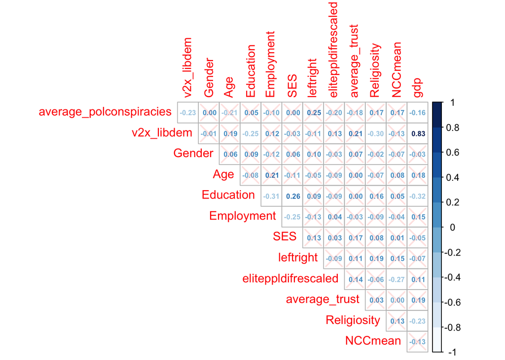

```r
#preliminary correlation analysis taking into account ordinal rankings.
#exclude country name- not included in main analysis! Only in object for graphing reasons.
corrdata<- regressiondata %>% select(average_polconspiracies, v2x_libdem, Gender, Age, Education, Employment,
                                     SES, leftright, eliteppldifrescaled, average_trust, Religiosity, NCCmean, gdp)
corrdata[] <- lapply(corrdata, function(x) as.numeric(as.character(x)))
corrmatrix<- cor(corrdata, method = "spearman", use = "pairwise.complete.obs")

#make plot of correlation matrix.
library(corrplot)
testRes = cor.mtest(corrmatrix, conf.level = 0.95)
corrplot(corrmatrix, method = 'number', type="upper", col = COL1('Blues', 10), number.cex = 0.6, p.mat = testRes$p, sig.level = 0.10,
         pch.col = '#F8766D33', diag=FALSE)
```

### Rename Categories from Numbers to Names; Set and Add Reference Levels; and Multiply Quality of Democracy Score (0-1) by 100 for Ease of Interpretation.

```r
#rename categories names for regression data.
regressiondata<- regressiondata %>% mutate(Gender=fct_recode(Gender, "Female"="0", "Male"= "1"), Education=fct_recode(Education, "None"="1", "Elementary"="2", "Secondary"="3", "University"="4", "Postgrad"="5"), SES=fct_recode(SES, "Lower-Class"="1", "Middle-Class"="2", "Upper-Class"="3"), Employment=fct_recode(Employment, "Full-Time"="1", "Part-Time"="2", "Retired"="3", "Unemployed"="4", "Student"="5", "Other"="9"), Religiosity=fct_recode(Religiosity, "Not Religious"="0", "Religious"="1"))


#check how many NAs in each variable, NAs could be meaningful for gender/religiosity.
regressiondata %>% summarise_all(~ sum(is.na(.)))
```

```
## # A tibble: 1 × 15
##   average_polconspiracies v2x_libdem Gender   Age Education Employment   SES
##                     <int>      <int>  <int> <int>     <int>      <int> <int>
## 1                      66          0    100     3       225          7    44
## # ℹ 8 more variables: leftright <int>, eliteppldif <int>, average_trust <int>,
## #   Religiosity <int>, NCCmean <int>, gdp <int>, country_name <int>,
## #   eliteppldifrescaled <int>
```

```r
#gender=100, Religiosity=405

#calculate percentage of NAs.
colMeans(is.na(regressiondata))
```

```
## average_polconspiracies              v2x_libdem                  Gender
##            0.0108232207            0.0000000000            0.0163988193
##                     Age               Education              Employment
##            0.0004919646            0.0368973434            0.0011479173
##                     SES               leftright             eliteppldif
##            0.0072154805            0.0052476222            0.0072154805
##           average_trust             Religiosity                 NCCmean
##            0.0111511971            0.0664152181            0.0450967530
##                     gdp            country_name     eliteppldifrescaled
##            0.0000000000            0.0000000000            0.0072154805
```

```r
#Mostly insignificant, 6.6% Religiosity.

#An NA answer for gender might not always mean non-binary... but we should create a "don't know" category for religiosity.
regressiondata$Religiosity <- fct_na_value_to_level(regressiondata$Religiosity, level = "Other/Don't Know")

#reset reference category in Education from "none" to "university".
regressiondata<- regressiondata %>% mutate(Education=fct_relevel(Education, "University"))

#multiply liberal democracy index by 100 for ease of interpretation.
regressiondata$v2x_libdemrescaled<- regressiondata$v2x_libdem *100
```

### Bivariate Analysis.

```r
#bivariate analysis.
lm1<- lm(formula= average_polconspiracies ~ v2x_libdemrescaled, data=regressiondata)

#table of bivariate analysis:
library(sjPlot)
modelone<-tab_model(lm1, show.se=TRUE, show.p=TRUE, show.fstat = TRUE, show.obs=TRUE,
          string.est="Coefficients", string.pred = "Variables", string.p="P-value", string.se = "Std. Error", emph.p=TRUE,
          pred.labels = c("Intercept", "Quality of Democracy"), dv.labels = "Average Belief in Political Conspiracy Theories",
          p.style="numeric_stars", CSS = list(css.thead = "text-align:center; padding-bottom:0.2cm;", css.tdata="padding:0.11cm;"))
modelone
```

Average Belief in Political Conspiracy Theories

Variables

Coefficients

Std. Error

CI

P-value

Intercept

4.76 ***

0.14

4.48 – 5.03

**<0.001**

Quality of Democracy

-0.04 ***

0.00

-0.04 – -0.03

**<0.001**

Observations

6032

R<sup>2</sup> / R<sup>2</sup> adjusted

0.062 / 0.062

- p<0.05 ** p<0.01 *** p<0.001

### Multivariate Analysis.

```r
#analysis with controls.
lm2<- lm(formula=average_polconspiracies~v2x_libdemrescaled + Gender + Age+ Education+ Employment+ SES+ leftright+ average_trust+
           Religiosity+NCCmean + gdp, data=regressiondata)

#table of exclusionary strategy:
modeltwo<-tab_model(lm2, show.se=TRUE, show.p=TRUE, show.fstat = TRUE, show.obs=TRUE,  show.reflvl = TRUE,
                    string.est="Coefficients", string.pred = "Variables", string.p="P-value", string.se = "Std. Error", emph.p=TRUE,
                    pred.labels = c("Intercept", "Quality of Democracy", "Male", "Age", "No Education", "Elementary Education", "Secondary Education",
                                    "Post-Grad Degree", "Employed Part-Time", "Retired", "Unemployed", "Student", "Other Employment",
                                    "Middle-Class", "Upper Class", "Left-Right Scale Placement", "Average Political Trust", "Religious", "NA Religion",
                                    "Average Need For Cognitive Closure", "GDP"), dv.labels = "Average Belief in Political Conspiracy Theories", p.style="numeric_stars", CSS = list(css.thead = "text-align:center; padding-bottom:0.2cm;", css.tdata="padding:0.11cm;"))

modeltwo
```

Average Belief in Political Conspiracy Theories

Variables

Coefficients

Std. Error

CI

P-value

Intercept

3.91 ***

0.28

3.36 – 4.45

**<0.001**

Quality of Democracy

-0.04 ***

0.00

-0.05 – -0.03

**<0.001**

Male

0.05

0.03

-0.01 – 0.11

0.076

Age

-0.01 ***

0.00

-0.01 – -0.01

**<0.001**

No Education

0.10

0.15

-0.18 – 0.39

0.485

Elementary Education

0.14 **

0.05

0.05 – 0.24

**0.004**

Secondary Education

0.08 *

0.03

0.01 – 0.15

**0.019**

Post-Grad Degree

0.03

0.04

-0.05 – 0.11

0.489

Employed Part-Time

-0.09 *

0.04

-0.18 – -0.00

**0.042**

Retired

-0.25 ***

0.05

-0.35 – -0.15

**<0.001**

Unemployed

-0.04

0.06

-0.16 – 0.07

0.448

Student

-0.04

0.08

-0.20 – 0.12

0.626

Other Employment

-0.01

0.06

-0.13 – 0.11

0.826

Middle-Class

-0.12 ***

0.03

-0.18 – -0.05

**<0.001**

Upper Class

0.07

0.07

-0.06 – 0.21

0.275

Left-Right Scale Placement

0.09 ***

0.01

0.08 – 0.10

**<0.001**

Average Political Trust

-0.07 ***

0.01

-0.08 – -0.06

**<0.001**

Religious

0.18 ***

0.03

0.12 – 0.24

**<0.001**

NA Religion

0.06

0.06

-0.05 – 0.17

0.303

Average Need For Cognitive Closure

0.26 ***

0.02

0.22 – 0.30

**<0.001**

GDP

0.00 ***

0.00

0.00 – 0.00

**<0.001**

Observations

5357

R<sup>2</sup> / R<sup>2</sup> adjusted

0.215 / 0.212

- p<0.05 ** p<0.01 *** p<0.001

### Effect Size Regression.

```r
#normalize data to explore effect size of predictors.
scaled_merged_data<- regressiondata
numeric_cols <- sapply(scaled_merged_data, is.numeric)
scaled_merged_data[numeric_cols] <- scale(scaled_merged_data[numeric_cols])

#effect size/standardized model.
lm3<- lm(formula=average_polconspiracies~v2x_libdemrescaled + Gender + Age+ Education+ Employment+ SES+ leftright+ average_trust+
           Religiosity+NCCmean + gdp, data=scaled_merged_data)

#table without dummy variables for effect size:
standardizedmodel<-tab_model(lm3, terms=c("v2x_libdemrescaled", "Age", "leftright", "average_trust", "NCCmean", "gdp"), show.se=TRUE, show.p=TRUE, show.fstat = TRUE, show.obs=TRUE,
                    string.est="Coefficients", string.pred = "Variables", string.p="P-value", string.se = "Std. Error", emph.p=TRUE,
                    pred.labels = c("Quality of Democracy", "Age", "Left-Right Scale Placement", "Average Political Trust",
                                    "Average Need For Cognitive Closure", "GDP"),
                    dv.labels = "Average Belief in Political Conspiracy Theories",
                    p.style="numeric_stars", CSS = list(css.thead = "text-align:center; padding-bottom:0.2cm;", css.tdata="padding:0.11cm;"))

standardizedmodel
```

Average Belief in Political Conspiracy Theories

Variables

Coefficients

Std. Error

CI

P-value

Quality of Democracy

-0.27 ***

0.03

-0.33 – -0.22

**<0.001**

Age

-0.17 ***

0.02

-0.20 – -0.14

**<0.001**

Left-Right Scale Placement

0.21 ***

0.01

0.19 – 0.24

**<0.001**

Average Political Trust

-0.18 ***

0.01

-0.20 – -0.15

**<0.001**

Average Need For Cognitive Closure

0.15 ***

0.01

0.12 – 0.17

**<0.001**

GDP

0.18 ***

0.03

0.13 – 0.24

**<0.001**

Observations

5357

R<sup>2</sup> / R<sup>2</sup> adjusted

0.215 / 0.212

- p<0.05 ** p<0.01 *** p<0.001

### Diagnostic Plots and Multicollinearity Check.

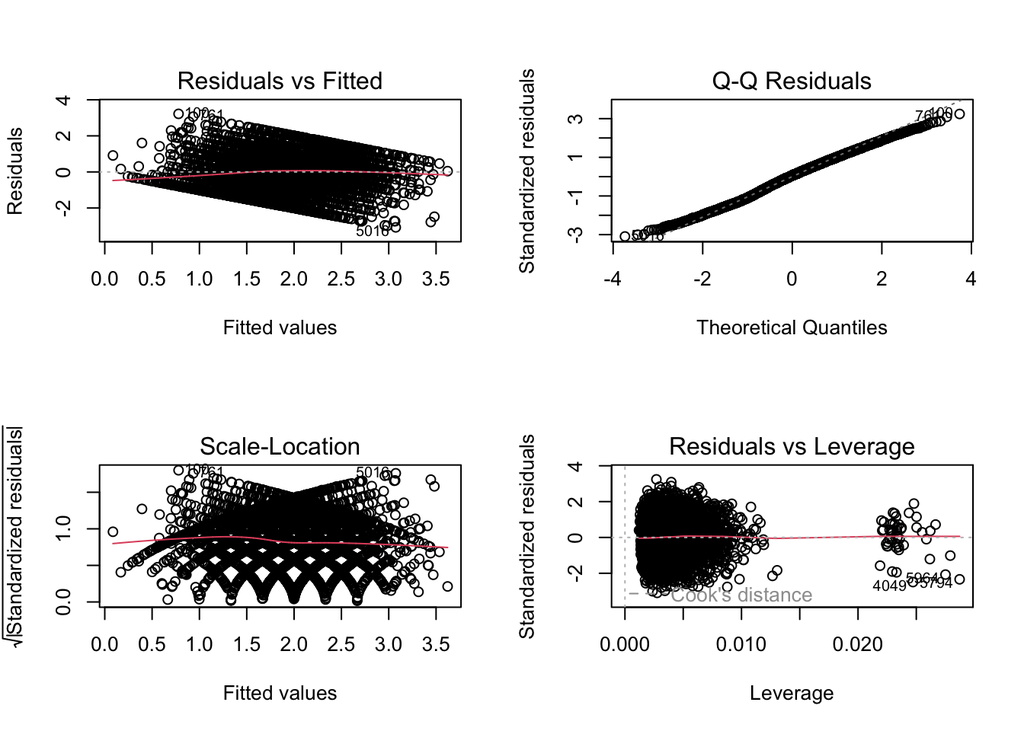

```r
#diagnostic plots for multivariate linear regression:
par(mfrow = c(2, 2))
plot(lm2)
```

```r
#testing for multicollinearity.
vif(lm2)
```

```
##                        GVIF Df GVIF^(1/(2*Df))
## v2x_libdemrescaled 4.833911  1        2.198616
## Gender             1.069307  1        1.034073
## Age                1.774169  1        1.331979
## Education          1.524515  4        1.054123
## Employment         2.111820  5        1.077620
## SES                1.237322  2        1.054680
## leftright          1.110938  1        1.054010
## average_trust      1.158371  1        1.076277
## Religiosity        1.181835  2        1.042652
## NCCmean            1.081169  1        1.039793
## gdp                4.926512  1        2.219575
```

### Mediation Analysis.

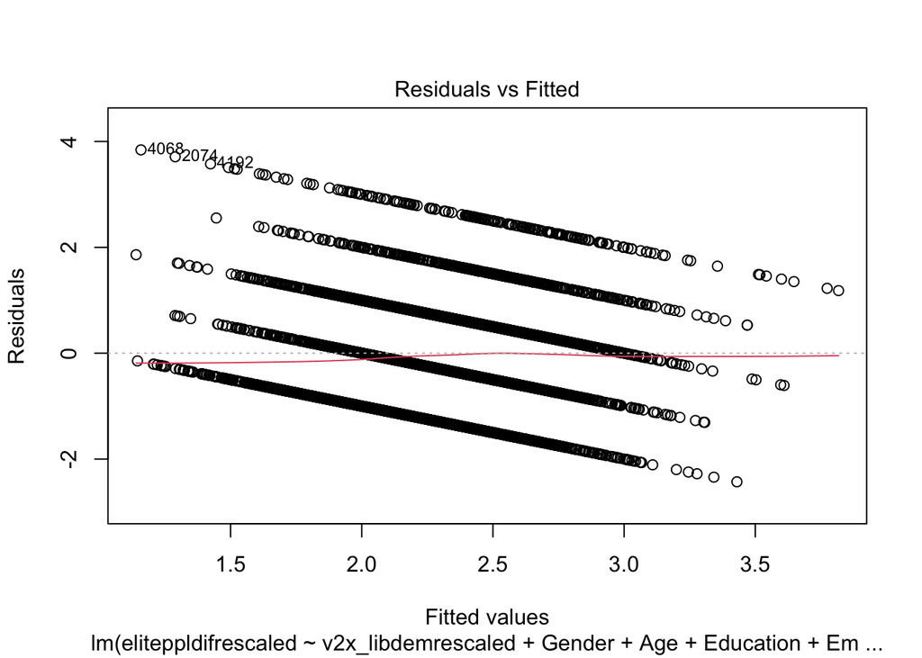

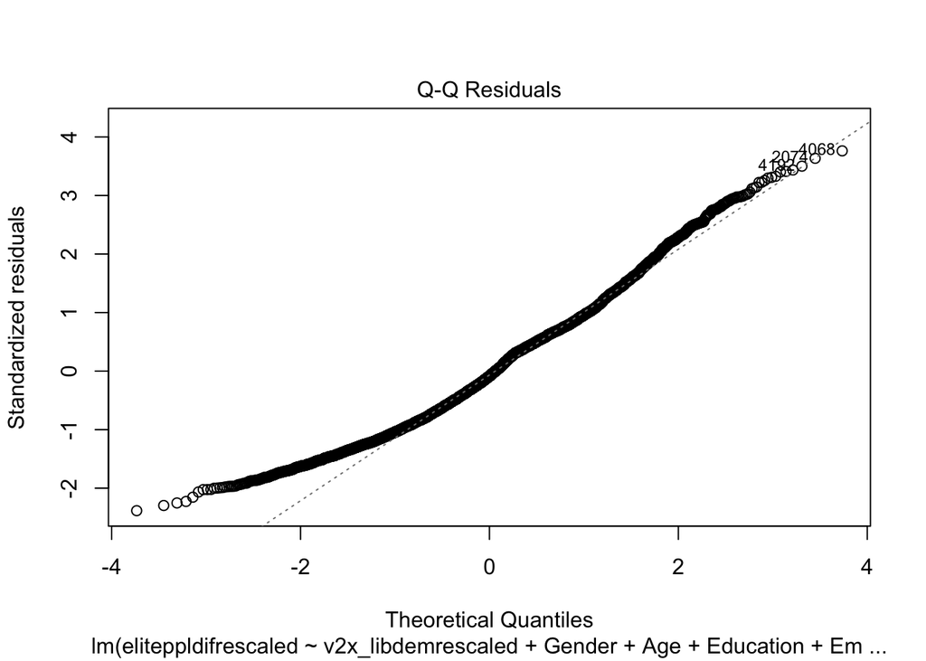

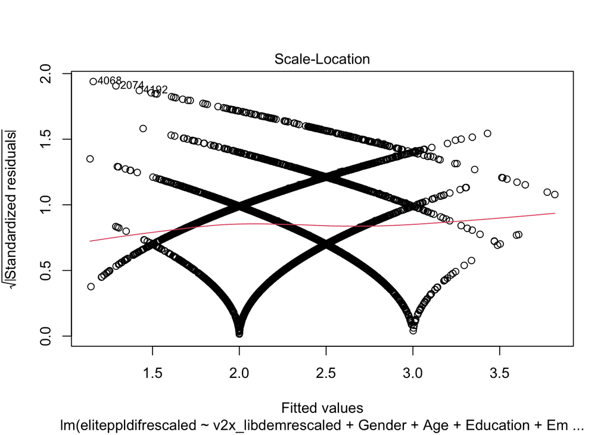

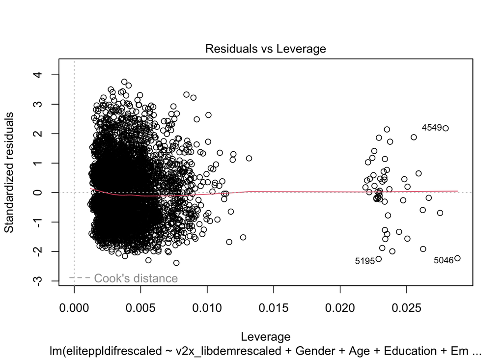

```r
#na's dropped dataset:
#In order to run a mediation analysis, we need to have regression models of the same size. So dropping all na's before for these specific variables is necessary:
nasdropped<- regressiondata %>% drop_na(v2x_libdemrescaled, average_polconspiracies, eliteppldifrescaled, Gender, Age, Education,
                                        Employment, SES, leftright, average_trust, Religiosity, NCCmean, gdp)

#inclusionary strategy using Barron & Kenny's model:

#step one, total effect of x on y taking into account alternative explanations:
#summary(lm2)

#Step two: does X have a significant relationship with M (X->M)?
eliteppldif<- lm(formula=eliteppldifrescaled~v2x_libdemrescaled + Gender + Age+ Education+ Employment+ SES+ leftright+ average_trust+
                   Religiosity+NCCmean + gdp, data=nasdropped)

#Step three: how is the relationship between X&Y affected with M? What is the relationship between M and Y?
mediationmodel<- lm(average_polconspiracies~v2x_libdemrescaled + eliteppldifrescaled+ Gender + Age
                    + Education+ Employment+ SES+ leftright+ average_trust+
                      Religiosity+NCCmean + gdp, data=nasdropped)
#diagnostic plots. Relatively normal, slight tail skew but sample is large enough for it to be okay.
plot(eliteppldif)
```

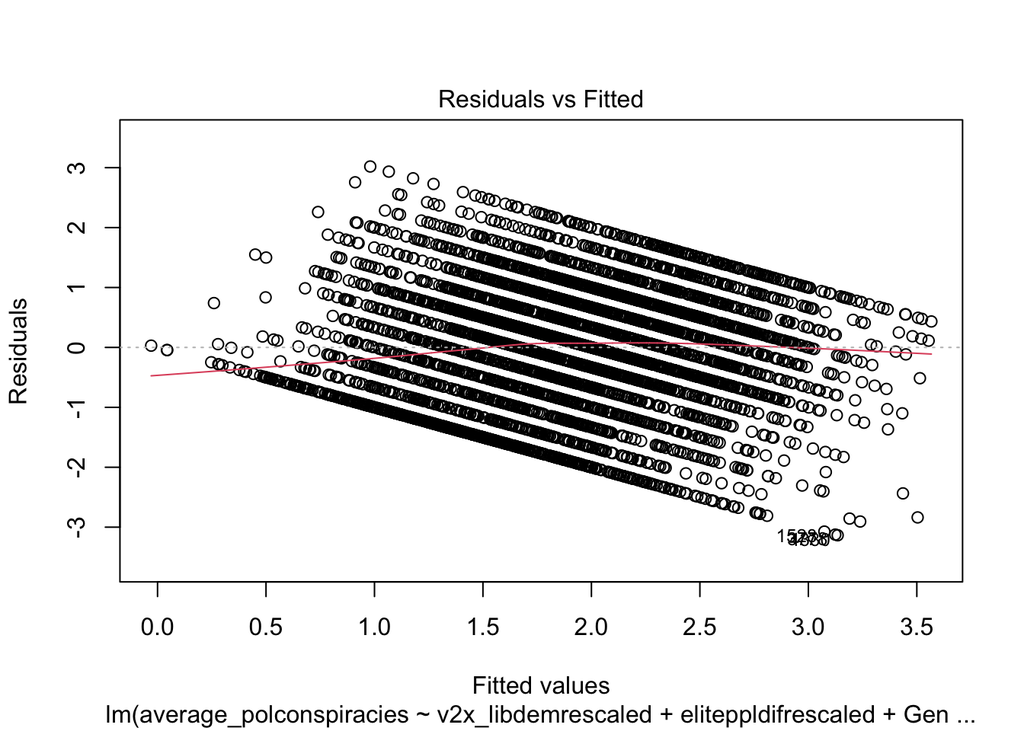

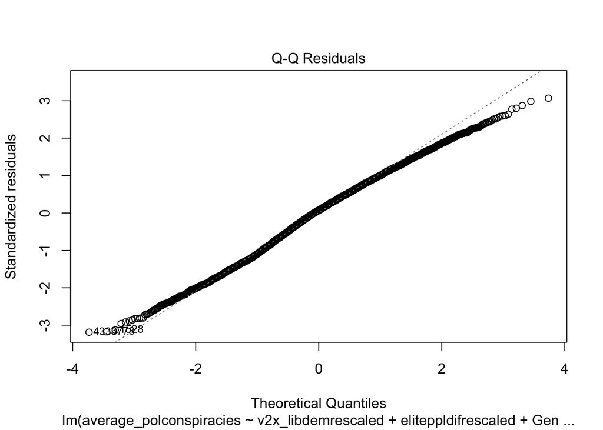

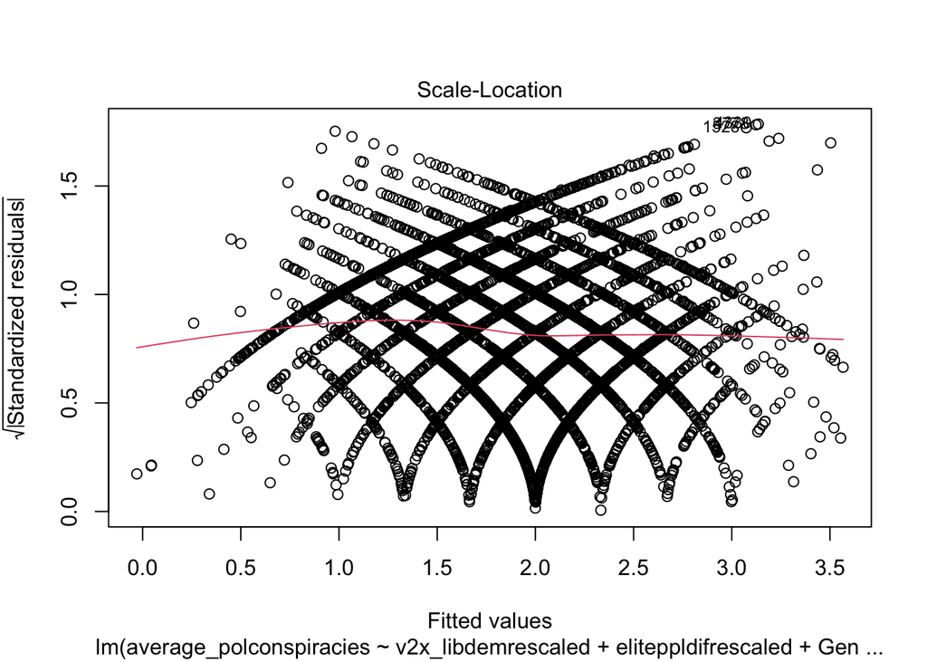

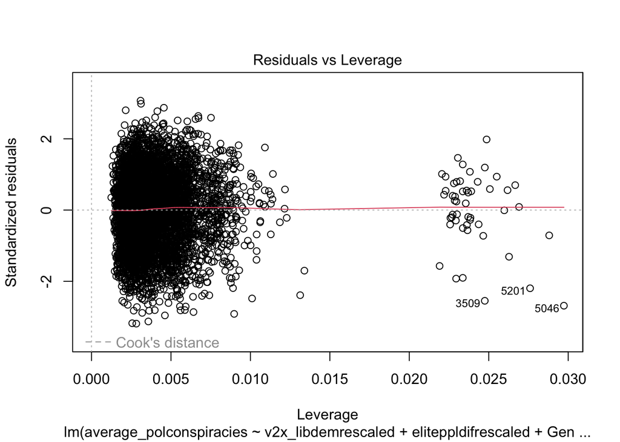

```r
plot(mediationmodel)
```